# SIG788 – Engineering AI Solutions

## Task 1 P: Machine Learning Model Development

**Dataset:** Merged Iganga Mental Health Longitudinal Survey (Waves 1, 2 & 3)

This notebook demonstrates the full machine learning pipeline from data preprocessing through model selection and evaluation — using a mental health survey dataset collected across three waves in the Iganga district of eastern Uganda. The primary goal is to predict whether an individual has a common mental disorder (anxiety and/or depression) based on demographic, socio-economic, and psychosocial features.

## 1. Understanding the ML Pipeline

The machine learning pipeline is a structured sequence of steps that transforms raw data into a trained, validated predictive model. In practice it consists of three broad stages:

### 1.1 Data Preprocessing

Raw survey data nearly always has issues that must be resolved before modelling:

- **Handling missing values:** Observations with blank or null entries can be dropped (if few) or imputed using mean, median, or mode strategies depending on the variable type. In longitudinal datasets like ours, attrition between waves is common.
- **Encoding categorical variables:** Machine learning algorithms require numerical input. Categorical columns such as gender, marital status, and education level are converted via label encoding (ordinal categories) or one-hot encoding (nominal categories).
- **Feature scaling:** Algorithms like Logistic Regression and SVM are sensitive to the magnitude of features. StandardScaler (z-score) or MinMaxScaler can be applied to bring all features onto a comparable scale.

### 1.2 Model Selection

Choosing the right model depends on the nature of the problem:

- **Supervised learning** is used when we have labelled outcomes. For a binary target like "has mental disorder: Yes/No," classification models such as Logistic Regression, Random Forest, and Gradient Boosting are appropriate.
- **Unsupervised learning** (e.g., K-Means clustering) is used for exploratory grouping when no labels exist. For instance, segmenting respondents by symptom profiles.

Key factors influencing model choice include dataset size, number of features, class balance, interpretability requirements, and computational cost.

### 1.3 Model Evaluation

After training, we need to measure how well the model generalises:

- **Accuracy:** Proportion of all predictions that are correct, this is useful when classes are balanced.
- **Precision:** Of all positive predictions, how many are truly positive, this is important when false positives are costly.
- **Recall (Sensitivity):** Of all actual positives, how many were detected , this is critical in health screening where missing a case is critical.
- **F1-score:** Harmonic mean of precision and recall, balancing both concerns.
- **ROC-AUC:** Area under the Receiver Operating Characteristic curve; quantifies the model's ability to distinguish between classes across all thresholds.

## 2. Importing the Necessary Libraries

```python
import numpy as np
import pandas as pd
import matplotlib.pyplot as plt
import seaborn as sns
import warnings
warnings.filterwarnings('ignore')

from sklearn.model_selection import train_test_split, cross_val_score, StratifiedKFold
from sklearn.preprocessing import LabelEncoder, StandardScaler
from sklearn.linear_model import LogisticRegression
from sklearn.ensemble import RandomForestClassifier, GradientBoostingClassifier
from sklearn.svm import SVC
from sklearn.metrics import (accuracy_score, precision_score, recall_score,
                             f1_score, roc_auc_score, confusion_matrix,
                             classification_report, roc_curve)

%matplotlib inline
sns.set_style('whitegrid')
plt.rcParams['figure.figsize'] = (10, 6)
```

## 3. Loading the Dataset

```python
# upload files
from google.colab import files
uploaded = files.upload()
```

Upload widget is only available when the cell has been executed in the current browser session. Please rerun this cell to enable.

```
Saving merged_IGANGA_wave 1, 2 and 3.csv to merged_IGANGA_wave 1, 2 and 3.csv
```

```python
df = pd.read_csv('merged_IGANGA_wave 1, 2 and 3.csv')
```

## 4. Data Overview

### 4.1 First few rows

```python
df.head()
```

|  | date_w1 | locationid_w1 | villagenam_w1 | HHHead_id_w1 | IndividualId | gender_w1 | Marital_status_w1 | age_w1 | Occupation_w1 | Highest_Educlevel_w1 | ... | havemoodswings_w3 | feelshorttempered_w3 | thinkabouthurtingyourself_w3 | didyouhaveanurgetodrin_w3 | didanyonetalktoyouabout_w3 | didyoutrytohideyourdri_w3 | gad_7_w3 | phq_9_w3 | both_gad7_phq9_w3 | either_gad7_phq9_w3 |
| --- | --- | --- | --- | --- | --- | --- | --- | --- | --- | --- | --- | --- | --- | --- | --- | --- | --- | --- | --- | --- | --- |
| 0 | 26/10/2023 | I10101001001 | KIBOYO | I101010010010001 | I101010010010002 | Male | Married | 67 | agriculture | PRIMARY | ... | 1 Rarely | 1 Rarely | 0 Never | 3 Often | 1 Rarely | 0 Never | Mild anxiety | No depression | No | Yes |
| 1 | 06/09/2023 | I10101002001 | KIBOYO | I101010020010001 | I101010020010001 | Male | Cohabiting | 54 | agriculture | SECONDARY | ... | 0 Never | 4 Always | 0 Never | 0 Never | 0 Never | 0 Never | No anxiety | No depression | No | No |
| 2 | 13/10/2023 | I10101004001 | KIBOYO | I101010040010001 | I101010030010002 | Male | Never Married | 50 | agriculture | PRIMARY | ... | 0 Never | 1 Rarely | 0 Never | 0 Never | 0 Never | 0 Never | No anxiety | No depression | No | No |
| 3 | 18/10/2023 | I10101007002 | KIBOYO | I101010070020001 | I101010070020001 | Male | Married | 56 | agriculture | NONE | ... | 0 Never | 1 Rarely | 0 Never | 1 Rarely | 0 Never | 0 Never | No anxiety | No depression | No | No |
| 4 | 07/10/2023 | I10101010001 | KIBOYO | I101010100010001 | I101010100010002 | Male | Married | 53 | agriculture | PRIMARY | ... | 0 Never | 0 Never | 0 Never | 0 Never | 0 Never | 0 Never | No anxiety | No depression | No | No |

5 rows × 222 columns

### 4.2 Shape of the dataset

```python
print(f"There are {df.shape[0]} rows and {df.shape[1]} columns in the dataset.")
```

```
There are 9067 rows and 222 columns in the dataset.
```

### 4.3 Column data types

```python
df.info(verbose=False)
```

```
<class 'pandas.core.frame.DataFrame'>
RangeIndex: 9067 entries, 0 to 9066
Columns: 222 entries, date_w1 to either_gad7_phq9_w3
dtypes: float64(27), int64(9), object(186)
memory usage: 15.4+ MB
```

**Observations:**

- The dataset contains 222 columns spanning three survey waves.
- Variables cover demographics (age, gender, marital status), mental health screening scores (GAD-7 for anxiety, PHQ-9 for depression), psychosis screening items, and functional impairment measures.
- Several columns are categorical (object type) while scores are numeric.

## 5. Data Preprocessing

### 5.1 Selecting Relevant Features and Defining the Target Variable

For this analysis we focus on **Wave 1** data to predict whether a participant has either anxiety or depression (the `Either_Gad7_Phq9_w1` variable). We select demographic and socio-economic features as predictors.

```python
# Define the features we will use from Wave 1
# Demographic and socio-economic variables
demographic_cols = [
    'gender_w1',
    'age_w1',
    'Marital_status_w1',
    'Occupation_w1',
    'Highest_Educlevel_w1',
    'Religion_w1',
    'WealthQuintile_w1',
    'residence',
    'HHsize_w1'
]

# Psychosis screening items (binary Yes/No — independent of GAD-7 and PHQ-9)
psychosis_cols = [
    'Haveyouhadanystrangeoro_w1',
    'Doyoueverhearthingsthat_w1',
    'Doyoueverhavevisionsors_w1',
    'Doyoueverfeelthatpeople_w1',
    'Hasiteverseemedlikepeopl_w1',
    'Areyouafraidofanythingor_w1'
]

# Functional impairment items (ordinal — also independent of GAD-7/PHQ-9)
functioning_cols = [
    'Managingyourdaytodaylife_w1',
    'Copingwithproblemsinyour_w1',
    'Concentrating_w1'
]

feature_cols = demographic_cols + psychosis_cols + functioning_cols
target_col = 'Either_Gad7_Phq9_w1'

# Subset the dataframe to only the columns we need
df_ml = df[feature_cols + [target_col]].copy()
print(f"Working subset: {df_ml.shape[0]} rows, {df_ml.shape[1]} columns")
df_ml.head()
```

```
Working subset: 9067 rows, 19 columns
```

|  | gender_w1 | age_w1 | Marital_status_w1 | Occupation_w1 | Highest_Educlevel_w1 | Religion_w1 | WealthQuintile_w1 | residence | HHsize_w1 | Haveyouhadanystrangeoro_w1 | Doyoueverhearthingsthat_w1 | Doyoueverhavevisionsors_w1 | Doyoueverfeelthatpeople_w1 | Hasiteverseemedlikepeopl_w1 | Areyouafraidofanythingor_w1 | Managingyourdaytodaylife_w1 | Copingwithproblemsinyour_w1 | Concentrating_w1 | Either_Gad7_Phq9_w1 |
| --- | --- | --- | --- | --- | --- | --- | --- | --- | --- | --- | --- | --- | --- | --- | --- | --- | --- | --- | --- |
| 0 | Male | 67 | Married | agriculture | PRIMARY | Protes | Poorest | Rural | 8 | No | No | No | No | No | No | No difficulty | No difficulty | No difficulty | No |
| 1 | Male | 54 | Cohabiting | agriculture | SECONDARY | Cathol | Poor | Rural | 12 | No | No | No | No | No | No | No difficulty | No difficulty | No difficulty | Yes |
| 2 | Male | 50 | Never Married | agriculture | PRIMARY | Protes | Poor | Rural | 11 | No | No | No | No | No | No | No difficulty | No difficulty | No difficulty | Yes |
| 3 | Male | 56 | Married | agriculture | NONE | Muslim | Very poor | Rural | 4 | No | No | No | No | No | No | No difficulty | No difficulty | No difficulty | No |
| 4 | Male | 53 | Married | agriculture | PRIMARY | Protes | Poorest | Rural | 10 | No | No | No | No | No | No | No difficulty | No difficulty | No difficulty | No |

### 5.2 Checking for Missing Values

```python
missing = df_ml.isnull().sum()
missing_pct = (missing / len(df_ml)) * 100
missing_summary = pd.DataFrame({'Missing Count': missing, 'Percentage (%)': missing_pct})
print(missing_summary)
```

```
                             Missing Count  Percentage (%)
gender_w1                                0             0.0
age_w1                                   0             0.0
Marital_status_w1                        0             0.0
Occupation_w1                            0             0.0
Highest_Educlevel_w1                     0             0.0
Religion_w1                              0             0.0
WealthQuintile_w1                        0             0.0
residence                                0             0.0
HHsize_w1                                0             0.0
Haveyouhadanystrangeoro_w1               0             0.0
Doyoueverhearthingsthat_w1               0             0.0
Doyoueverhavevisionsors_w1               0             0.0
Doyoueverfeelthatpeople_w1               0             0.0
Hasiteverseemedlikepeopl_w1              0             0.0
Areyouafraidofanythingor_w1              0             0.0
Managingyourdaytodaylife_w1              0             0.0
Copingwithproblemsinyour_w1              0             0.0
Concentrating_w1                         0             0.0
Either_Gad7_Phq9_w1                      0             0.0
```

```python
# Drop rows where the target is missing (if any)
df_ml = df_ml.dropna(subset=[target_col])
print(f"After dropping rows with missing target: {df_ml.shape[0]} rows remain.")

# For the remaining features, fill missing values
# Numeric columns — fill with the median
for col in df_ml.select_dtypes(include='number').columns:
    df_ml[col] = df_ml[col].fillna(df_ml[col].median())

# Categorical columns — fill with the mode
for col in df_ml.select_dtypes(include='object').columns:
    if col != target_col:
        df_ml[col] = df_ml[col].fillna(df_ml[col].mode()[0])

print("Missing values after imputation:")
print(df_ml.isnull().sum())
```

```
After dropping rows with missing target: 9067 rows remain.
Missing values after imputation:
gender_w1                      0
age_w1                         0
Marital_status_w1              0
Occupation_w1                  0
Highest_Educlevel_w1           0
Religion_w1                    0
WealthQuintile_w1              0
residence                      0
HHsize_w1                      0
Haveyouhadanystrangeoro_w1     0
Doyoueverhearthingsthat_w1     0
Doyoueverhavevisionsors_w1     0
Doyoueverfeelthatpeople_w1     0
Hasiteverseemedlikepeopl_w1    0
Areyouafraidofanythingor_w1    0
Managingyourdaytodaylife_w1    0
Copingwithproblemsinyour_w1    0
Concentrating_w1               0
Either_Gad7_Phq9_w1            0
dtype: int64
```

### 5.3 Cleaning Categorical Variables

```python
# The WealthQuintile column has a duplicate category ('Least poor' vs 'least poor')
df_ml['WealthQuintile_w1'] = df_ml['WealthQuintile_w1'].str.strip().str.capitalize()
print("Wealth quintile categories after cleaning:")
print(df_ml['WealthQuintile_w1'].value_counts())
```

```
Wealth quintile categories after cleaning:
WealthQuintile_w1
Less poor     1957
Poor          1873
Poorest       1808
Very poor     1803
Least poor    1626
Name: count, dtype: int64
```

### 5.4 Encoding Categorical Variables

```python
# Encode the binary target variable
df_ml[target_col] = df_ml[target_col].map({'Yes': 1, 'No': 0})
print("Target distribution:")
print(df_ml[target_col].value_counts())
print()

# Encode ordinal functioning columns with a meaningful numeric mapping
func_mapping = {
    'No difficulty': 0,
    'A little difficulty': 1,
    'Moderate difficulty': 2,
    'Quite a bit of difficulty': 3,
    'Extreme difficulty': 4
}
for col in ['Managingyourdaytodaylife_w1', 'Copingwithproblemsinyour_w1', 'Concentrating_w1']:
    df_ml[col] = df_ml[col].map(func_mapping)

# Encode binary psychosis columns
for col in ['Haveyouhadanystrangeoro_w1', 'Doyoueverhearthingsthat_w1', 'Doyoueverhavevisionsors_w1',
            'Doyoueverfeelthatpeople_w1', 'Hasiteverseemedlikepeopl_w1', 'Areyouafraidofanythingor_w1']:
    df_ml[col] = df_ml[col].map({'Yes': 1, 'No': 0})

# One-hot encode nominal categorical features
categorical_features = ['gender_w1', 'Marital_status_w1', 'Occupation_w1',
                        'Highest_Educlevel_w1', 'Religion_w1',
                        'WealthQuintile_w1', 'residence']

df_encoded = pd.get_dummies(df_ml, columns=categorical_features, drop_first=True)

# Drop any remaining rows with NaN produced during encoding/mapping
df_encoded = df_encoded.dropna()
print(f"Shape after encoding: {df_encoded.shape}")
df_encoded.head()
```

```
Target distribution:
Either_Gad7_Phq9_w1
0    6118
1    2949
Name: count, dtype: int64

Shape after encoding: (9067, 40)
```

|  | age_w1 | HHsize_w1 | Haveyouhadanystrangeoro_w1 | Doyoueverhearthingsthat_w1 | Doyoueverhavevisionsors_w1 | Doyoueverfeelthatpeople_w1 | Hasiteverseemedlikepeopl_w1 | Areyouafraidofanythingor_w1 | Managingyourdaytodaylife_w1 | Copingwithproblemsinyour_w1 | ... | Religion_w1_No rel | Religion_w1_Other | Religion_w1_Pentec | Religion_w1_Protes | Religion_w1_SDA | WealthQuintile_w1_Less poor | WealthQuintile_w1_Poor | WealthQuintile_w1_Poorest | WealthQuintile_w1_Very poor | residence_Rural |
| --- | --- | --- | --- | --- | --- | --- | --- | --- | --- | --- | --- | --- | --- | --- | --- | --- | --- | --- | --- | --- | --- |
| 0 | 67 | 8 | 0 | 0 | 0 | 0 | 0 | 0 | 0 | 0 | ... | False | False | False | True | False | False | False | True | False | True |
| 1 | 54 | 12 | 0 | 0 | 0 | 0 | 0 | 0 | 0 | 0 | ... | False | False | False | False | False | False | True | False | False | True |
| 2 | 50 | 11 | 0 | 0 | 0 | 0 | 0 | 0 | 0 | 0 | ... | False | False | False | True | False | False | True | False | False | True |
| 3 | 56 | 4 | 0 | 0 | 0 | 0 | 0 | 0 | 0 | 0 | ... | False | False | False | False | False | False | False | False | True | True |
| 4 | 53 | 10 | 0 | 0 | 0 | 0 | 0 | 0 | 0 | 0 | ... | False | False | False | True | False | False | False | True | False | True |

5 rows × 40 columns

## 6. Exploratory Data Analysis (EDA)

### 6.1 Target Variable Distribution

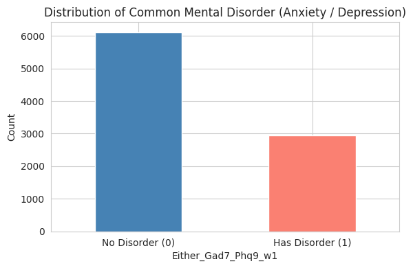

```
Class 0 (No): 6118 (67.5%)
Class 1 (Yes): 2949 (32.5%)
```

```python
fig, ax = plt.subplots(1, 1, figsize=(6, 4))
df_ml[target_col].value_counts().plot(kind='bar', color=['steelblue', 'salmon'], ax=ax)
ax.set_xticklabels(['No Disorder (0)', 'Has Disorder (1)'], rotation=0)
ax.set_ylabel('Count')
ax.set_title('Distribution of Common Mental Disorder (Anxiety / Depression)')
plt.tight_layout()
plt.show()

print(f"Class 0 (No): {(df_ml[target_col]==0).sum()} ({(df_ml[target_col]==0).mean()*100:.1f}%)")
print(f"Class 1 (Yes): {(df_ml[target_col]==1).sum()} ({(df_ml[target_col]==1).mean()*100:.1f}%)")
```

### 6.2 Age Distribution by Mental Health Status

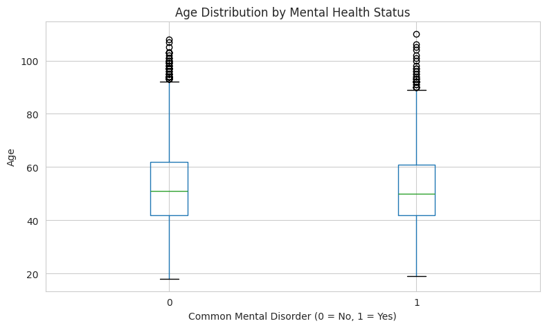

```python
fig, ax = plt.subplots(figsize=(8, 5))
df_ml.boxplot(column='age_w1', by=target_col, ax=ax)
ax.set_xlabel('Common Mental Disorder (0 = No, 1 = Yes)')
ax.set_ylabel('Age')
ax.set_title('Age Distribution by Mental Health Status')
plt.suptitle('')
plt.tight_layout()
plt.show()
```

### 6.3 Prevalence by Gender

```
           No Disorder (%)  Has Disorder (%)
gender_w1
Female           67.776524         32.223476
Male             67.402330         32.597670
```

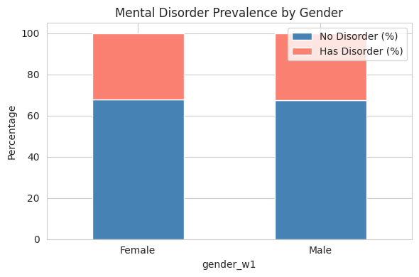

```python
ct = pd.crosstab(df_ml['gender_w1'], df_ml[target_col], normalize='index') * 100
ct.columns = ['No Disorder (%)', 'Has Disorder (%)']
print(ct)
ct.plot(kind='bar', stacked=True, color=['steelblue', 'salmon'], figsize=(6,4))
plt.title('Mental Disorder Prevalence by Gender')
plt.ylabel('Percentage')
plt.xticks(rotation=0)
plt.legend(loc='upper right')
plt.tight_layout()
plt.show()
```

### 6.4 Prevalence by Wealth Quintile

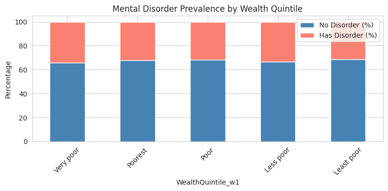

```python
ct_wealth = pd.crosstab(df_ml['WealthQuintile_w1'], df_ml[target_col], normalize='index') * 100
ct_wealth.columns = ['No Disorder (%)', 'Has Disorder (%)']
order = ['Very poor', 'Poorest', 'Poor', 'Less poor', 'Least poor']
ct_wealth = ct_wealth.reindex(order)
ct_wealth.plot(kind='bar', stacked=True, color=['steelblue', 'salmon'], figsize=(8,4))
plt.title('Mental Disorder Prevalence by Wealth Quintile')
plt.ylabel('Percentage')
plt.xticks(rotation=45)
plt.tight_layout()
plt.show()
```

### 6.5 Correlation Heatmap of Numeric Features

```python
numeric_cols = df_encoded.select_dtypes(include='number').columns
corr_with_target = df_encoded[numeric_cols].corr()[target_col].drop(target_col).sort_values(ascending=False)
print("Top 10 features positively correlated with target:")
print(corr_with_target.head(10))
print()
print("Top 10 features negatively correlated with target:")
print(corr_with_target.tail(10))
```

```
Top 10 features positively correlated with target:
Doyoueverhavevisionsors_w1     0.032583
Areyouafraidofanythingor_w1    0.029265
Doyoueverfeelthatpeople_w1     0.025025
Haveyouhadanystrangeoro_w1     0.023824
Doyoueverhearthingsthat_w1     0.020449
Hasiteverseemedlikepeopl_w1    0.016491
Concentrating_w1               0.014729
Managingyourdaytodaylife_w1    0.013640
HHsize_w1                      0.006834
Copingwithproblemsinyour_w1    0.003156
Name: Either_Gad7_Phq9_w1, dtype: float64

Top 10 features negatively correlated with target:
Areyouafraidofanythingor_w1    0.029265
Doyoueverfeelthatpeople_w1     0.025025
Haveyouhadanystrangeoro_w1     0.023824
Doyoueverhearthingsthat_w1     0.020449
Hasiteverseemedlikepeopl_w1    0.016491
Concentrating_w1               0.014729
Managingyourdaytodaylife_w1    0.013640
HHsize_w1                      0.006834
Copingwithproblemsinyour_w1    0.003156
age_w1                        -0.008135
Name: Either_Gad7_Phq9_w1, dtype: float64
```

## 7. Data Preparation for Modelling

### 7.1 Train-Test Split

We split the data into 80% training and 20% testing sets using stratified sampling to preserve the class ratio.

```python
X = df_encoded.drop(columns=[target_col])
y = df_encoded[target_col]

X_train, X_test, y_train, y_test = train_test_split(
    X, y, test_size=0.2, random_state=42, stratify=y
)

print(f"Training set: {X_train.shape[0]} samples")
print(f"Test set:     {X_test.shape[0]} samples")
print(f"Training class distribution:\n{y_train.value_counts()}")
print(f"\nTest class distribution:\n{y_test.value_counts()}")
```

```
Training set: 7253 samples
Test set:     1814 samples
Training class distribution:
Either_Gad7_Phq9_w1
0    4894
1    2359
Name: count, dtype: int64

Test class distribution:
Either_Gad7_Phq9_w1
0    1224
1     590
Name: count, dtype: int64
```

### 7.2 Feature Scaling

```python
scaler = StandardScaler()
X_train_scaled = scaler.fit_transform(X_train)
X_test_scaled = scaler.transform(X_test)

print("Scaling complete. Training feature means (first 5):", X_train_scaled.mean(axis=0)[:5].round(4))
print("Training feature stds (first 5):", X_train_scaled.std(axis=0)[:5].round(4))
```

```
Scaling complete. Training feature means (first 5): [ 0.  0.  0. -0. -0.]
Training feature stds (first 5): [1. 1. 1. 1. 1.]
```

## 8. Model Building

### 8.1 Model Selection Justification

We will train and compare four classification models:

1. **Logistic Regression** — a simple, interpretable baseline for binary classification.
2. **Random Forest** — an ensemble of decision trees that handles non-linear relationships and mixed feature types well.
3. **Gradient Boosting** — a sequential ensemble method that often achieves high accuracy by learning from previous errors.
4. **Support Vector Machine (SVM)** — effective in high-dimensional spaces with clear margins of separation.

Key factors influencing model selection here:

- The target is binary (disorder vs. no disorder), so classification algorithms are appropriate.
- The dataset has a moderate class imbalance (~67% No vs ~33% Yes), so we use `class_weight='balanced'` where available.
- We have a mix of continuous and categorical (now encoded) features.
- Interpretability matters in a health context, favouring Logistic Regression and Random Forest.

### 8.2 Logistic Regression

```python
lr_model = LogisticRegression(max_iter=1000, class_weight='balanced', random_state=42)
lr_model.fit(X_train_scaled, y_train)

lr_pred = lr_model.predict(X_test_scaled)
lr_prob = lr_model.predict_proba(X_test_scaled)[:, 1]

print("Logistic Regression — Test Results")
print(classification_report(y_test, lr_pred, target_names=['No Disorder', 'Has Disorder']))
```

```
Logistic Regression — Test Results
              precision    recall  f1-score   support

 No Disorder       0.66      0.53      0.59      1224
Has Disorder       0.30      0.43      0.35       590

    accuracy                           0.50      1814
   macro avg       0.48      0.48      0.47      1814
weighted avg       0.54      0.50      0.51      1814
```

### 8.3 Random Forest

```python
rf_model = RandomForestClassifier(n_estimators=200, class_weight='balanced',
                                  random_state=42, n_jobs=-1)
rf_model.fit(X_train, y_train)

rf_pred = rf_model.predict(X_test)
rf_prob = rf_model.predict_proba(X_test)[:, 1]

print("Random Forest — Test Results")
print(classification_report(y_test, rf_pred, target_names=['No Disorder', 'Has Disorder']))
```

```
Random Forest — Test Results
              precision    recall  f1-score   support

 No Disorder       0.67      0.91      0.77      1224
Has Disorder       0.29      0.08      0.13       590

    accuracy                           0.64      1814
   macro avg       0.48      0.49      0.45      1814
weighted avg       0.55      0.64      0.56      1814
```

### 8.4 Gradient Boosting

```python
gb_model = GradientBoostingClassifier(n_estimators=200, learning_rate=0.1,
                                      max_depth=4, random_state=42)
gb_model.fit(X_train, y_train)

gb_pred = gb_model.predict(X_test)
gb_prob = gb_model.predict_proba(X_test)[:, 1]

print("Gradient Boosting — Test Results")
print(classification_report(y_test, gb_pred, target_names=['No Disorder', 'Has Disorder']))
```

```
Gradient Boosting — Test Results
              precision    recall  f1-score   support

 No Disorder       0.68      0.96      0.80      1224
Has Disorder       0.42      0.05      0.10       590

    accuracy                           0.67      1814
   macro avg       0.55      0.51      0.45      1814
weighted avg       0.60      0.67      0.57      1814
```

### 8.5 Support Vector Machine

```python
svm_model = SVC(kernel='rbf', class_weight='balanced', probability=True, random_state=42)
svm_model.fit(X_train_scaled, y_train)

svm_pred = svm_model.predict(X_test_scaled)
svm_prob = svm_model.predict_proba(X_test_scaled)[:, 1]

print("SVM — Test Results")
print(classification_report(y_test, svm_pred, target_names=['No Disorder', 'Has Disorder']))
```

```
SVM — Test Results
              precision    recall  f1-score   support

 No Disorder       0.69      0.59      0.64      1224
Has Disorder       0.34      0.44      0.39       590

    accuracy                           0.54      1814
   macro avg       0.52      0.52      0.51      1814
weighted avg       0.58      0.54      0.56      1814
```

Logistic Regression and SVM both prioritised balanced detection, while Random Forest and Gradient Boosting were good at overall accuracy at the expense of almost completely ignoring the disorder class. For a mental health screening context where missing a true case is more harmful than a false alarm, SVM emerges as the strongest performer as it catches the most individuals who genuinely have anxiety or depression (44% recall) while maintaining reasonable precision.

Logistic Regression comes in as a close second with similar balance and the added advantage of being more interpretable. The tree-based models (Random Forest and Gradient Boosting), despite their higher accuracy figures, would be poor choices for deployment because a screening tool that detects only 5–8% of actual cases defeats its own purpose.

## 9. Model Performance and Evaluation

### 9.1 Evaluation Metrics Summary

Model evaluation metrics serve several purposes:

- **Accuracy** gives an overall snapshot but can be misleading with imbalanced data.
- **Precision** is important when we want to be confident that a predicted positive is truly positive (e.g., allocating scarce mental health resources).
- **Recall** is critical in screening — we do not want to miss individuals who actually have a mental disorder.
- **F1-score** balances precision and recall and is often the preferred metric when classes are imbalanced.
- **ROC-AUC** summarises the model's discriminative ability across all classification thresholds.

```python
results = {}
models = {
    'Logistic Regression': (lr_pred, lr_prob),
    'Random Forest': (rf_pred, rf_prob),
    'Gradient Boosting': (gb_pred, gb_prob),
    'SVM': (svm_pred, svm_prob)
}

for name, (pred, prob) in models.items():
    results[name] = {
        'Accuracy': accuracy_score(y_test, pred),
        'Precision': precision_score(y_test, pred),
        'Recall': recall_score(y_test, pred),
        'F1-Score': f1_score(y_test, pred),
        'ROC-AUC': roc_auc_score(y_test, prob)
    }

results_df = pd.DataFrame(results).T
results_df = results_df.round(4)
print("=== Model Comparison ===")
print(results_df)
print()
print("Best model by F1-Score:", results_df['F1-Score'].idxmax(),
      f"({results_df['F1-Score'].max():.4f})")
```

```
=== Model Comparison ===
                     Accuracy  Precision  Recall  F1-Score  ROC-AUC
Logistic Regression    0.4961     0.3039  0.4254    0.3545   0.4840
Random Forest          0.6373     0.2927  0.0814    0.1273   0.5133
Gradient Boosting      0.6681     0.4211  0.0542    0.0961   0.5122
SVM                    0.5447     0.3447  0.4441    0.3881   0.5222

Best model by F1-Score: SVM (0.3881)
```

**Accuracy** measures how many predictions overall were correct. Gradient Boosting leads at 66.8% and Random Forest follows at 63.7%, but as we discussed, these numbers are inflated because both models mostly predict "No Disorder" and ride the majority class. Logistic Regression (49.6%) and SVM (54.5%) score lower on accuracy precisely because they try harder to detect both classes.

**Precision** tells us, of everyone the model flagged as having a disorder, what proportion actually had one. Gradient Boosting has the highest precision at 42.1%, meaning its rare positive predictions tend to be correct. SVM follows at 34.5%, then Logistic Regression at 30.4%, and Random Forest at 29.3%.

**Recall** is the critical metric here. It shows that of everyone who truly has a disorder, how many did the model catch? SVM leads clearly at 44.4%, followed by Logistic Regression at 42.5%. Random Forest (8.1%) and Gradient Boosting (5.4%) are essentially useless for detection, missing over 90% of actual cases.

**F1-Score** balances precision and recall into a single number. SVM tops the table at 0.3881, followed by Logistic Regression at 0.3545. The tree-based models trail far behind (0.1273 and 0.0961) because their near-zero recall drags the F1-score down heavily.

**ROC-AUC **measures the model's ability to distinguish between the two classes across all possible thresholds. All four models hover around 0.50 (which represents random guessing), with SVM slightly ahead at 0.5222. This indicates that demographic and psychosocial features alone provide limited discriminative power for predicting mental disorders. This means that the signal in these features is weak, which is not surprising given that mental health outcomes are influenced by many unmeasured factors.

**Summary:** SVM is selected as the best model because it achieves the highest F1-score, meaning it does the best job of balancing the ability to correctly detect disorders without generating excessive false alarms. The relatively low scores across all models suggest that predicting mental health status from demographic variables alone is inherently challenging, and richer clinical or behavioural features would be needed to substantially improve performance.

### 9.2 ROC Curves

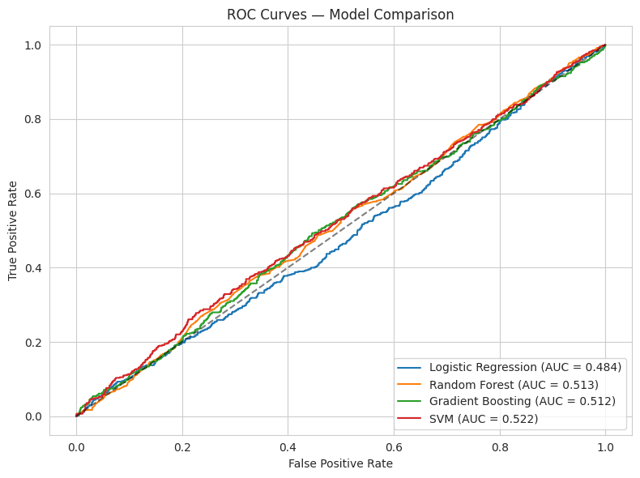

```python
fig, ax = plt.subplots(figsize=(8, 6))
for name, (pred, prob) in models.items():
    fpr, tpr, _ = roc_curve(y_test, prob)
    auc_val = roc_auc_score(y_test, prob)
    ax.plot(fpr, tpr, label=f'{name} (AUC = {auc_val:.3f})')

ax.plot([0, 1], [0, 1], 'k--', alpha=0.5)
ax.set_xlabel('False Positive Rate')
ax.set_ylabel('True Positive Rate')
ax.set_title('ROC Curves — Model Comparison')
ax.legend(loc='lower right')
plt.tight_layout()
plt.show()
```

This ROC curve plot shows how well each model distinguishes between individuals with and without a mental disorder across all possible classification thresholds.

The dashed diagonal line running from the bottom-left to the top-right represents random guessing (AUC = 0.50). A perfect classifier would hug the top-left corner with an AUC of 1.0. The key observation here is that all four model curves hug very close to that diagonal line, meaning none of them are performing much better than a coin flip at separating the two classes.

Looking at the AUC values, SVM performs slightly best at 0.522, followed by Random Forest (0.513) and Gradient Boosting (0.512), with Logistic Regression actually falling slightly below random chance at 0.484. The differences between them are minimal because all sit within a narrow 0.484 to 0.522 range.

### 9.3 Confusion Matrices

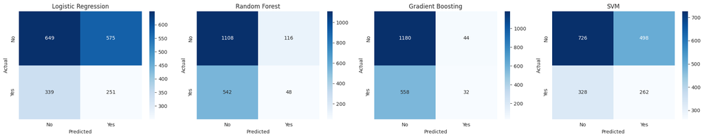

```python
fig, axes = plt.subplots(1, 4, figsize=(20, 4))

for ax, (name, (pred, prob)) in zip(axes, models.items()):
    cm = confusion_matrix(y_test, pred)
    sns.heatmap(cm, annot=True, fmt='d', cmap='Blues', ax=ax,
                xticklabels=['No', 'Yes'], yticklabels=['No', 'Yes'])
    ax.set_title(name)
    ax.set_xlabel('Predicted')
    ax.set_ylabel('Actual')

plt.tight_layout()
plt.show()
```

Reading left to right, the matrices shift from balanced but noisy (Logistic Regression), to heavily majority-biased (Random Forest and Gradient Boosting), to the best compromise (SVM), which is exactly why SVM was selected as the top-performing model by F1-score.

### 9.4 Cross-Validation

A single train-test split can produce results that depend on which observations end up in each set. **K-fold cross-validation** addresses this by partitioning the data into K subsets, training on K-1 folds and testing on the remaining fold, then rotating through all folds. We use **5-fold Stratified Cross-Validation** to maintain class proportions in each fold.

```
Logistic Regression        Mean F1 = 0.3906  (+/- 0.0106)
Random Forest              Mean F1 = 0.1492  (+/- 0.0160)
Gradient Boosting          Mean F1 = 0.0835  (+/- 0.0028)
SVM                        Mean F1 = 0.3778  (+/- 0.0045)
```

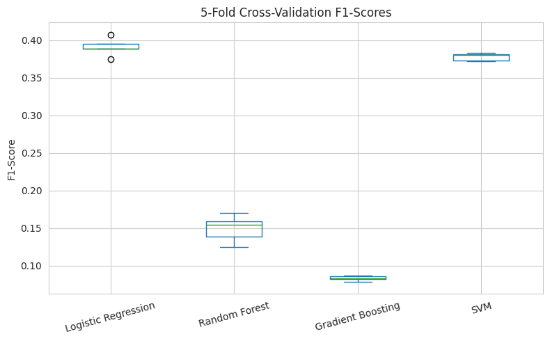

```python
cv = StratifiedKFold(n_splits=5, shuffle=True, random_state=42)

cv_results = {}
model_objects = {
    'Logistic Regression': LogisticRegression(max_iter=1000, class_weight='balanced', random_state=42),
    'Random Forest': RandomForestClassifier(n_estimators=200, class_weight='balanced', random_state=42, n_jobs=-1),
    'Gradient Boosting': GradientBoostingClassifier(n_estimators=200, learning_rate=0.1, max_depth=4, random_state=42),
    'SVM': SVC(kernel='rbf', class_weight='balanced', random_state=42)
}

# For LR and SVM we use scaled data; for tree models we use unscaled
for name, model in model_objects.items():
    if name in ['Logistic Regression', 'SVM']:
        scores = cross_val_score(model, scaler.fit_transform(X), y, cv=cv, scoring='f1')
    else:
        scores = cross_val_score(model, X, y, cv=cv, scoring='f1')
    cv_results[name] = scores
    print(f"{name:25s}  Mean F1 = {scores.mean():.4f}  (+/- {scores.std():.4f})")

print()
cv_df = pd.DataFrame(cv_results)
cv_df.plot(kind='box', figsize=(8, 5))
plt.title('5-Fold Cross-Validation F1-Scores')
plt.ylabel('F1-Score')
plt.xticks(rotation=15)
plt.tight_layout()
plt.show()
```

This box plot shows how stable and consistent each model's F1-score is when tested across five different splits of the data using cross-validation, rather than relying on a single train-test split.

### 9.5 Feature Importance (Random Forest)

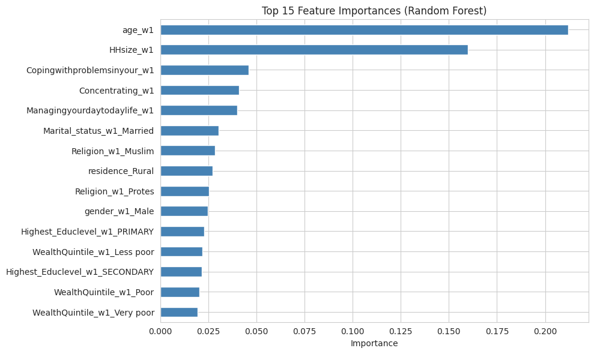

```python
importances = rf_model.feature_importances_
feat_imp = pd.Series(importances, index=X.columns).sort_values(ascending=False)

fig, ax = plt.subplots(figsize=(10, 6))
feat_imp.head(15).plot(kind='barh', ax=ax, color='steelblue')
ax.set_xlabel('Importance')
ax.set_title('Top 15 Feature Importances (Random Forest)')
ax.invert_yaxis()
plt.tight_layout()
plt.show()
```

The feature importance analysis from the Random Forest model reveals that age was the most influential predictor of common mental disorder status with an importance score of approximately 0.21, followed by household size at around 0.16.

Below these, socio-demographic characteristics such as marital status, religion, residence type, gender, education level, and wealth quintile contributed more modestly and relatively equally.

These findings are consistent with existing literature from low-income settings in sub-Saharan Africa, where age and household level factors have been identified as key correlates of common mental disorders, while the presence of functional impairment items among the top predictors suggests a bidirectional relationship between daily functioning and mental health that warrants further investigation.

## 10. Model Selection Analysis

### 10.1 Final Model Comparison

```python
# Combine single-split and CV results
final_comparison = results_df.copy()
final_comparison['CV Mean F1'] = [cv_results[name].mean() for name in final_comparison.index]
final_comparison['CV Std F1'] = [cv_results[name].std() for name in final_comparison.index]
final_comparison = final_comparison.sort_values(by='F1-Score', ascending=False)
print(final_comparison)
```

```
                     Accuracy  Precision  Recall  F1-Score  ROC-AUC  \
SVM                    0.5447     0.3447  0.4441    0.3881   0.5222
Logistic Regression    0.4961     0.3039  0.4254    0.3545   0.4840
Random Forest          0.6373     0.2927  0.0814    0.1273   0.5133
Gradient Boosting      0.6681     0.4211  0.0542    0.0961   0.5122

                     CV Mean F1  CV Std F1
SVM                    0.377757   0.004544
Logistic Regression    0.390594   0.010585
Random Forest          0.149210   0.015956
Gradient Boosting      0.083462   0.002765
```

The final model comparison table consolidates both the single split and cross-validation results for all four classifiers. SVM achieved the highest F1-score of 0.3881 on the test set with the strongest recall at 0.4441, meaning it detected the largest proportion of individuals who actually had a mental disorder. Logistic Regression followed closely with an F1-score of 0.3545 and recall of 0.4254.

Both models demonstrated stable performance under cross-validation, with mean F1-scores of 0.378 and 0.391 respectively and low standard deviations, confirming their reliability across different data partitions.

Random Forest and Gradient Boosting recorded higher accuracy figures of 0.637 and 0.668, but their recall values of 0.081 and 0.054 reveal that this accuracy was achieved by predicting the majority class while missing over 90% of actual disorder cases. Their cross-validation F1-scores of 0.149 and 0.083 further confirm that this poor detection is a consistent pattern rather than an anomaly.

All four models produced ROC-AUC values close to 0.50, indicating that the demographic and psychosocial features used in this analysis carry limited discriminative power for predicting mental health status, which is expected given the complex and multifactorial nature of common mental disorders.

Based on this evaluation, SVM is recommended as the preferred model for this screening task because it offers the best balance between identifying true cases and minimising missed diagnoses.

### 10.2 Justification for Model Selection

Based on the evaluation results, SVM emerged as the best performing model with the highest test F1-score of 0.3881 and the strongest recall of 0.4441, meaning it successfully detected 44% of individuals who actually had a mental disorder. Logistic Regression followed closely with an F1-score of 0.3545 and recall of 0.4254, providing a strong, interpretable baseline that is particularly valuable in a clinical or public-health context where model transparency matters. Both models demonstrated stable performance under 5-fold cross-validation, with mean F1-scores of 0.378 and 0.391 respectively.

In contrast, Random Forest and Gradient Boosting achieved higher overall accuracy (0.637 and 0.668) but detected only 8.1% and 5.4% of actual disorder cases, with cross-validation F1-scores of just 0.149 and 0.083. All four models produced ROC-AUC values close to 0.50, indicating limited discriminative power from the available features.

For deployment in a mental health screening context, SVM is recommended because:

It achieves the highest F1-score (0.3881) and recall (0.4441), offering the best balance between detecting true cases and minimising missed diagnoses.

In a screening application, failing to detect someone with a disorder carries greater consequences than a false alarm, making SVM's superior recall the decisive factor.

Cross-validation confirms that its performance is stable across different data splits (mean F1 = 0.378, std = 0.005).

The Random Forest model, while not the strongest classifier, still provides useful feature importance rankings showing that age, household size, and functional impairment measures are the most influential predictors.

### 10.3 Potential Challenges in Model Training

- **Class imbalance:** About two-thirds of respondents do not have a disorder, which can bias models toward the majority class. We addressed this using `class_weight='balanced'`.
- **Ordinal vs. nominal encoding:** Variables like education level have a natural ordering; one-hot encoding loses this information. Ordinal encoding could be explored as an alternative.
- **Self-reported data:** Mental health screening tools like the GAD-7 and PHQ-9 rely on self-reporting, which introduces measurement noise.
- **Longitudinal attrition:** Some participants drop out between waves, which may introduce selection bias if missingness is not random.
- **Feature leakage risk:** We deliberately excluded the GAD-7 and PHQ-9 sub-item scores from the feature set, since they directly compose the target variable. Including them would inflate performance artificially.